# Bootstrapping Exploration I

# How IPR changes with `mm` size?

We see how IPR change with number of bootstrap samples.

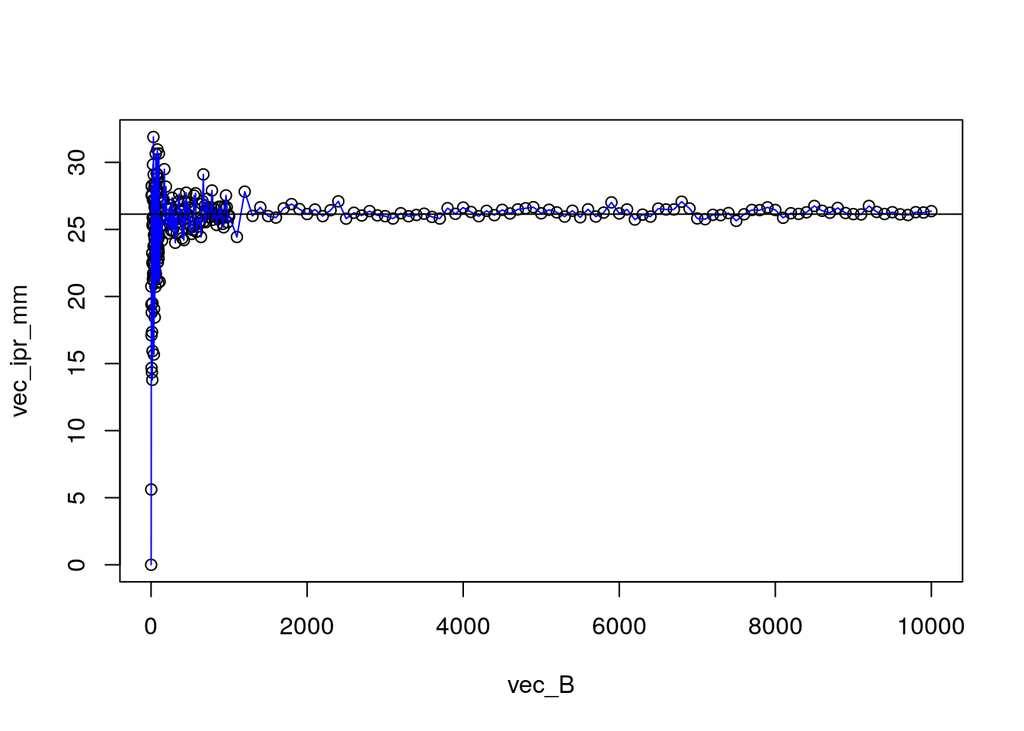

```r
vec_B = c(seq(1,100,by=1),seq(100,1000,by=10),seq(1000,10000,by=100))
len = length(vec_B)
vec_ipr_mm = rep(NA,len)
for (jj in 1:len){
  mm = vec_B[jj]
  vec_boots = rep(NA,mm)
  #set.seed(111)
  for (ii in 1:mm) {
    sample2 = sample(sample1,n,replace=TRUE)
    mean_sample = mean(sample2^2)
    vec_boots[ii] = mean_sample
    #print(paste(ii,";",jj))
  }
  quantile_vec = vec_boots %>% quantile(probs=c(.05,.5,.95))
  ipr =  quantile_vec[3] - quantile_vec[1]
  vec_ipr_mm[jj] = ipr
}

plot(vec_B,vec_ipr_mm)
lines(vec_B,vec_ipr_mm,col='blue')
abline(h=26.14091,col='black')
```

```r
#the black line is the bootstrap ipr with mm=500
#500 is sufficient to most of our problems
```

The black line is the IPR value for `mm=500`.

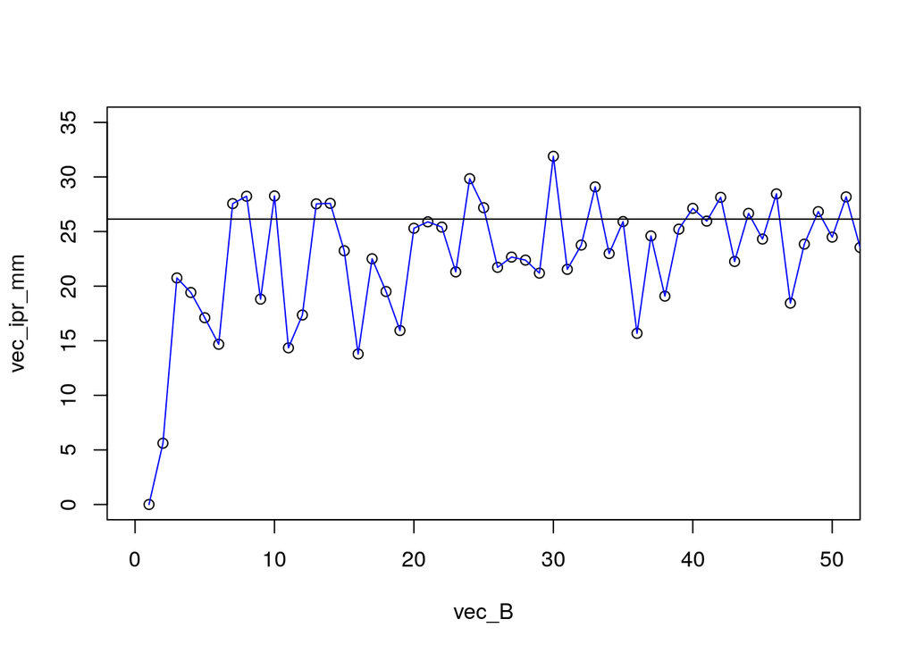

```r
xmin = 0
xmax = 50
ymin = 0
ymax = 35
plot(vec_B,vec_ipr_mm, xlim = c(xmin,xmax), ylim=c(ymin, ymax))
lines(vec_B,vec_ipr_mm,col='blue')
abline(h=26.14091,col='black')
```

```r
#a view closer to zero
```

Are there situations where we need an enormous amont of bootstrap samples?

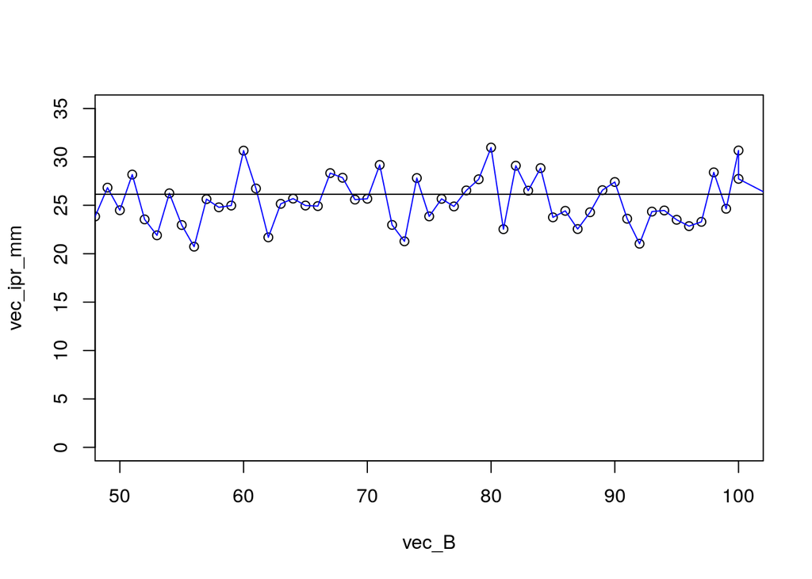

```r
xmin = 50
xmax = 100
ymin = 0
ymax = 35
plot(vec_B,vec_ipr_mm, xlim = c(xmin,xmax), ylim=c(ymin, ymax))
lines(vec_B,vec_ipr_mm,col='blue')
abline(h=26.14091,col='black')
```

```r
#moving a little to the right we can see how ipr
#stabilizes
```

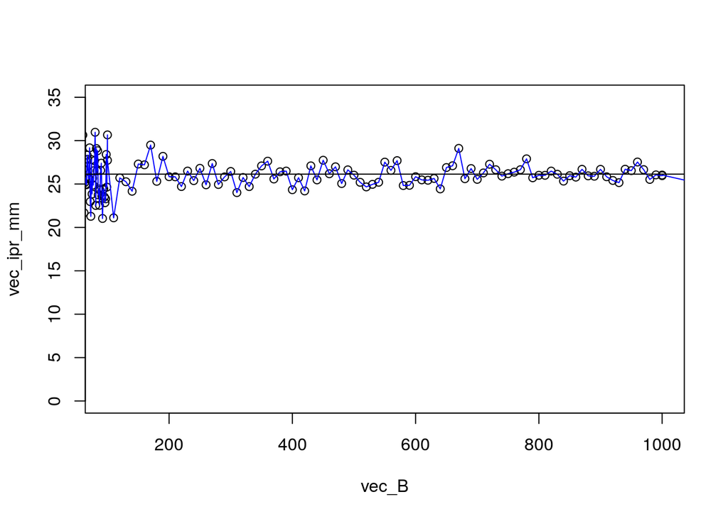

```r
xmin = 100
xmax = 1000
ymin = 0
ymax = 35
plot(vec_B,vec_ipr_mm, xlim = c(xmin,xmax), ylim=c(ymin, ymax))
lines(vec_B,vec_ipr_mm,col='blue')
abline(h=26.14091,col='black')
```

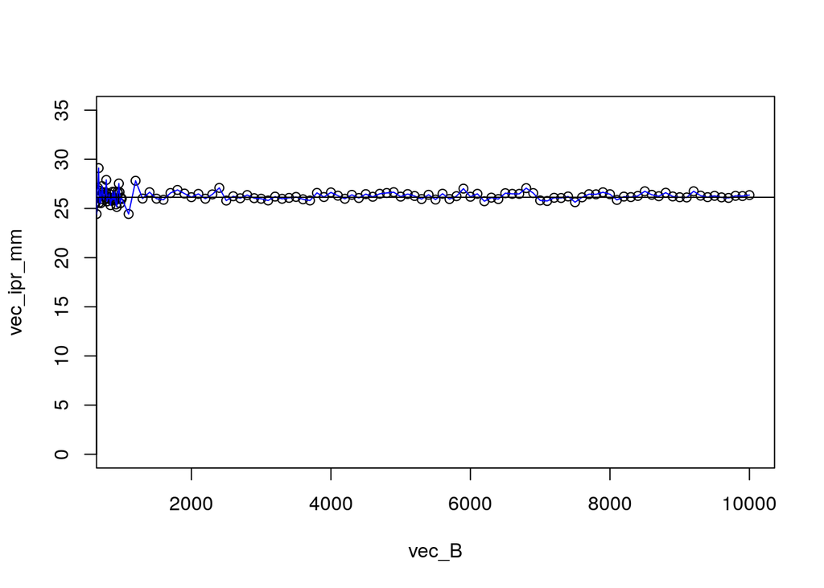

```r
xmin = 1000
xmax = 10000
ymin = 0
ymax = 35
plot(vec_B,vec_ipr_mm, xlim = c(xmin,xmax), ylim=c(ymin, ymax))
lines(vec_B,vec_ipr_mm,col='blue')
abline(h=26.14091,col='black')
```

All of the images above show the same graph in different zooms.

# Change sample size, impact in IPR

Here we investigate how changing the orignal sample size will change IPR.

The example below we use a sample size of 100, which is way smaller than 1000 which we used before. Let’s see how this change impacts IPR.

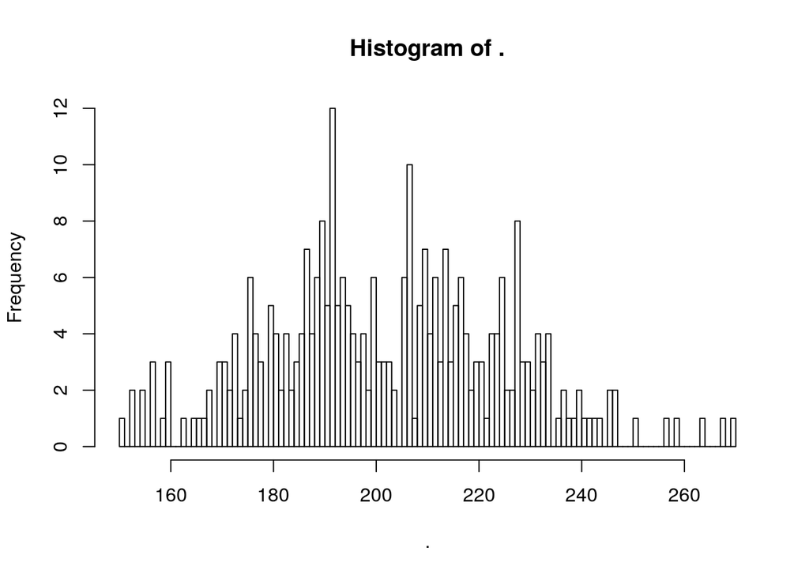

```r
# shrink test sample ----------------------------------------------------
#suppose now that we have only 100 observations in the test sample
sample1_1 = sample1[1:100]
#sample1_1 #smaller test sample

mm = 300 #300 we adopt as the default
vec_boots = rep(NA,mm)
set.seed(111)
len = length(sample1_1)
for (ii in 1:mm) {
  sample2 = sample(sample1_1,len,replace=TRUE)
  mean_sample = mean(sample2^2)
  vec_boots[ii] = mean_sample
  #print(ii)
}
vec_boots %>% hist(breaks=100)
```

```r
quantile_vec = vec_boots %>% quantile(probs=c(.05,.5,.95))
quantile_vec
```

```
##       5%      50%      95%
## 166.3975 200.9483 239.3798
```

```r
ipr =  quantile_vec[3] - quantile_vec[1]
ipr
```

```
##      95%
## 72.98228
```

This is bigger than 26.14091 (sample size of 1000). The obtained value of 72.98228 (sample size of 100) it is much bigger. That is we have much less confidence about our measure of MSE hence the dispertion measure is larger.

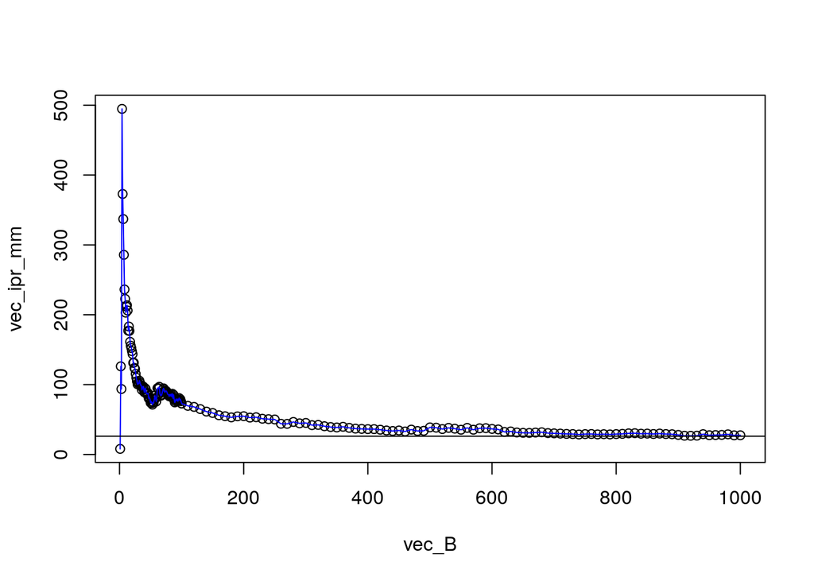

```r
#test sample size change, ipr change -------------------------------------
#let's see how ipr changes with test sample size
vec_B = c(seq(1,100,by=1),seq(100,1000,by=10))
len = length(vec_B)
vec_ipr_mm = rep(NA,len)
for (jj in 1:len){
  mm = vec_B[jj]
  sample1_1 = sample1[1:mm]
  sample1_1 #smaller test sample

  mm = 300 #300 we adopt as the standard
  vec_boots = rep(NA,mm)
  set.seed(111)
  len = length(sample1_1)
  for (ii in 1:mm) {
    sample2 = sample(sample1_1,len,replace=TRUE)
    mean_sample = mean(sample2^2)
    vec_boots[ii] = mean_sample
    #print(paste(ii,jj))
  }
  quantile_vec = vec_boots %>% quantile(probs=c(.05,.5,.95))
  ipr =  quantile_vec[3] - quantile_vec[1]
  vec_ipr_mm[jj] = ipr
}
plot(vec_B,vec_ipr_mm)
lines(vec_B,vec_ipr_mm,col='blue')
abline(h=26.14091,col='black')
```

This graph shows how IPR changes when we change sample size of bootstrap (and the test sample, MSE).

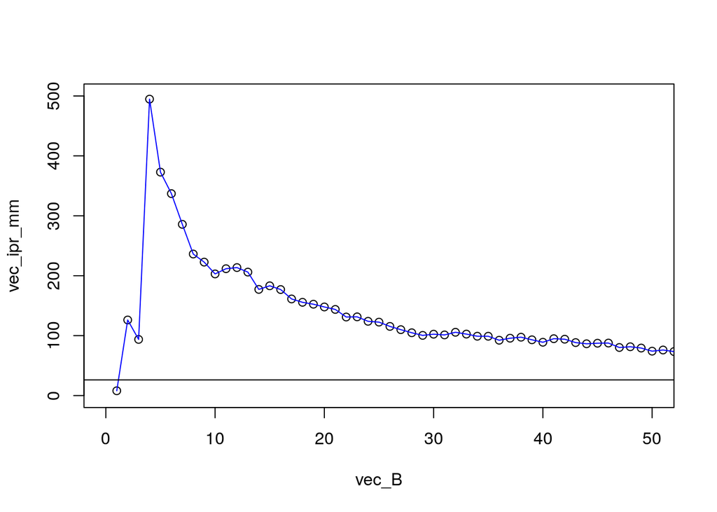

```r
xmin = 0
xmax = 50
ymin = 0
ymax = 500
plot(vec_B,vec_ipr_mm, xlim = c(xmin,xmax), ylim=c(ymin, ymax))
lines(vec_B,vec_ipr_mm,col='blue')
abline(h=26.14091,col='black')
```

This image is a closer view of the graph near 0.

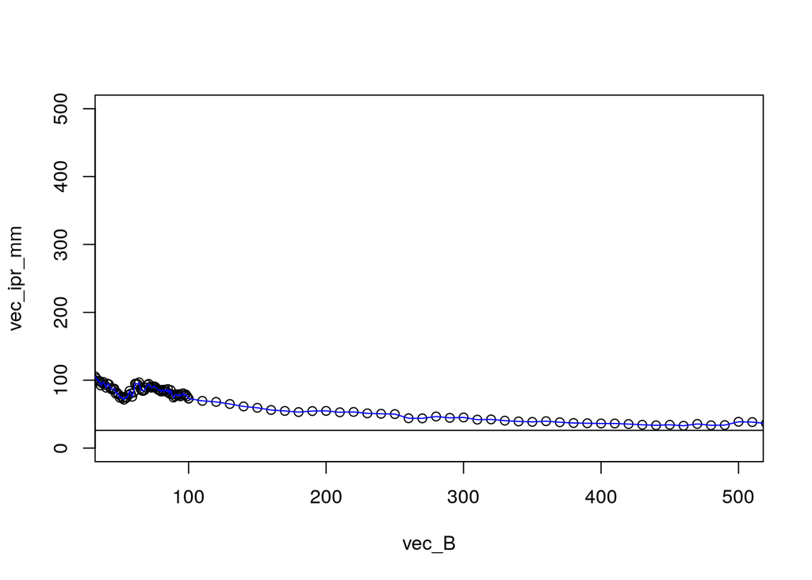

```r
xmin = 50
xmax = 500
ymin = 0
ymax = 500
plot(vec_B,vec_ipr_mm, xlim = c(xmin,xmax), ylim=c(ymin, ymax))
lines(vec_B,vec_ipr_mm,col='blue')
abline(h=26.14091,col='black')
```

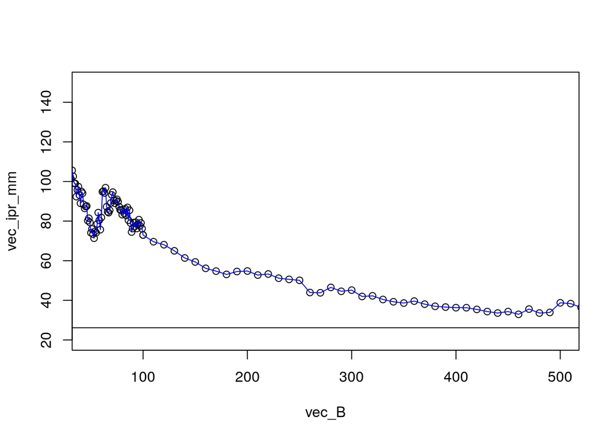

```r
xmin = 50
xmax = 500
ymin = 20
ymax = 150
plot(vec_B,vec_ipr_mm, xlim = c(xmin,xmax), ylim=c(ymin, ymax))
lines(vec_B,vec_ipr_mm,col='blue')
abline(h=26.14091,col='black')
```

Bootstrap procedures can be used to find distributions from estimators.

Some estimators have complicated distributions that are hard to find in an analytical way.

Also bootstraps can be used to increase the sample size of a statistical procedure. If for example we don’t have the sample size necessary to make IPR stabilize, we can build a larger sample by increasing the bootstrap sample size.

Usually in machine learning test sample size are larger than 300 observations.

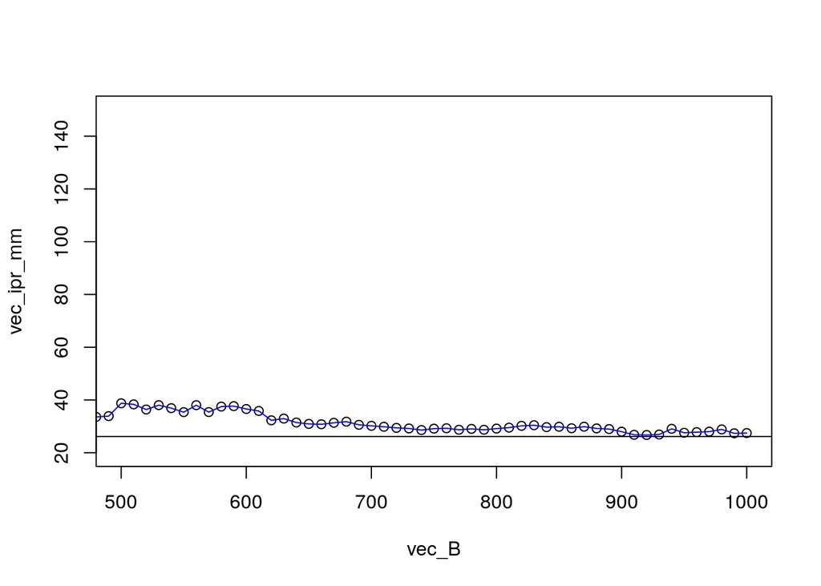

```r
xmin = 500
xmax = 1000
ymin = 20
ymax = 150
plot(vec_B,vec_ipr_mm, xlim = c(xmin,xmax), ylim=c(ymin, ymax))
lines(vec_B,vec_ipr_mm,col='blue')
abline(h=26.14091,col='black')
```

```r
#a view closer to zero
```

# Change variance, change IPR

Here we test how changing the variance of the DGP will change IPR.

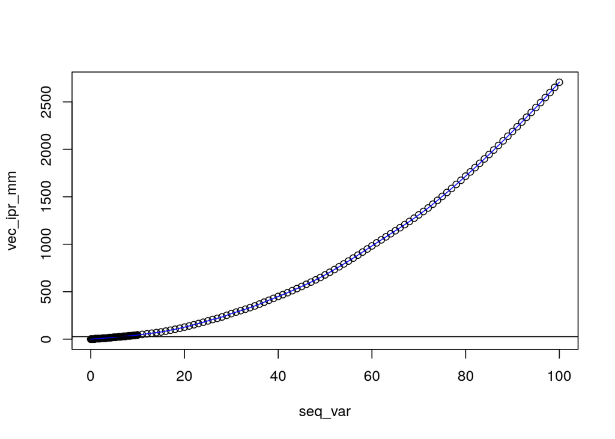

```r
#change variance of residuals, change ipr -------------------------------------
#how interpercentile range change with variance of residuals?
mean1=10
seq_var = c(seq(.01,1,by=.01),seq(1,10,by=.1),seq(10,100,by=1))
len = length(seq_var)
vec_ipr_mm = rep(NA,len)
set.seed(123)
for (ss in 1:len) {
  sig1 = seq_var[ss]
  sample1_2 = rnorm(1000,mean1,sig1)

  mm = 300 #300 we adopt as the standard
  vec_boots = rep(NA,mm)
  set.seed(111)
  for (ii in 1:mm) {
    sample2 = sample(sample1_2,len,replace=TRUE)
    mean_sample = mean(sample2^2)
    vec_boots[ii] = mean_sample
    #print(paste(ii,ss))
  }
  quantile_vec = vec_boots %>% quantile(probs=c(.05,.5,.95))
  ipr =  quantile_vec[3] - quantile_vec[1]
  vec_ipr_mm[ss] = ipr
}

plot(seq_var,vec_ipr_mm)
lines(seq_var,vec_ipr_mm,col='blue')
abline(h=26.14091,col='black')
```

```r
#the black line is the bootstrap ipr with mm=500
#ipr slowly decreases towards 26.15
#when we increase test sample size the
```

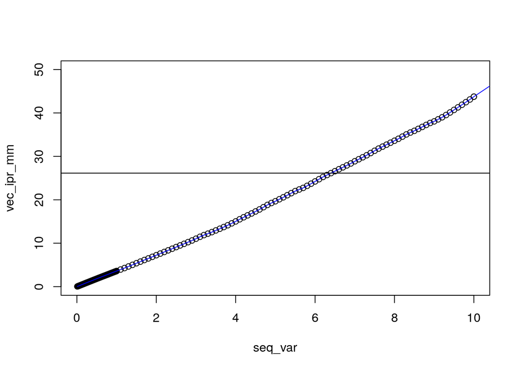

```r
xmin = 0
xmax = 10
ymin = 0
ymax = 50
plot(seq_var,vec_ipr_mm, xlim = c(xmin,xmax), ylim=c(ymin, ymax))
lines(seq_var,vec_ipr_mm,col='blue')
abline(h=26.14091,col='black')
```

Closer to zero the variance and IPR have a linear relationship.

# change variance, bootstrap sample size and IPR

```r
#test IPR, boots sample size, and variance of DGP -------------------------
vec_B = c(seq(10,1000,by=10),seq(1000,10000,by=200))
vec_var = c(1,10,50,100)
len_var = length(vec_var)
len = length(vec_B)
tb_var = data.frame(matrix(NA,nrow=len,ncol=len_var))
names(tb_var) = paste0("sd",as.character(vec_var))
for (kk in 1:len_var){
  set.seed(112)
  vv = vec_var[kk]
  sample2_1 = rnorm(10000,mean=10,sd=vv)
  vec_ipr_mm = rep(NA,len)
  for (jj in 1:len) {
    nn = vec_B[jj]
    sample1_1 = sample2_1[1:nn]

    mm = 300 #300 we adopt as the standard
    vec_boots = rep(NA,mm)
    set.seed(111)
    for (ii in 1:mm) {
      sample2 = sample(sample1_1,nn,replace=TRUE)
      mean_sample = mean(sample2^2)
      vec_boots[ii] = mean_sample
    }
    quantile_vec = vec_boots %>% quantile(probs=c(.05,.5,.95))
    ipr =  quantile_vec[3] - quantile_vec[1]
    vec_ipr_mm[jj] = ipr
  }
  tb_var[,kk] = vec_ipr_mm
}
```

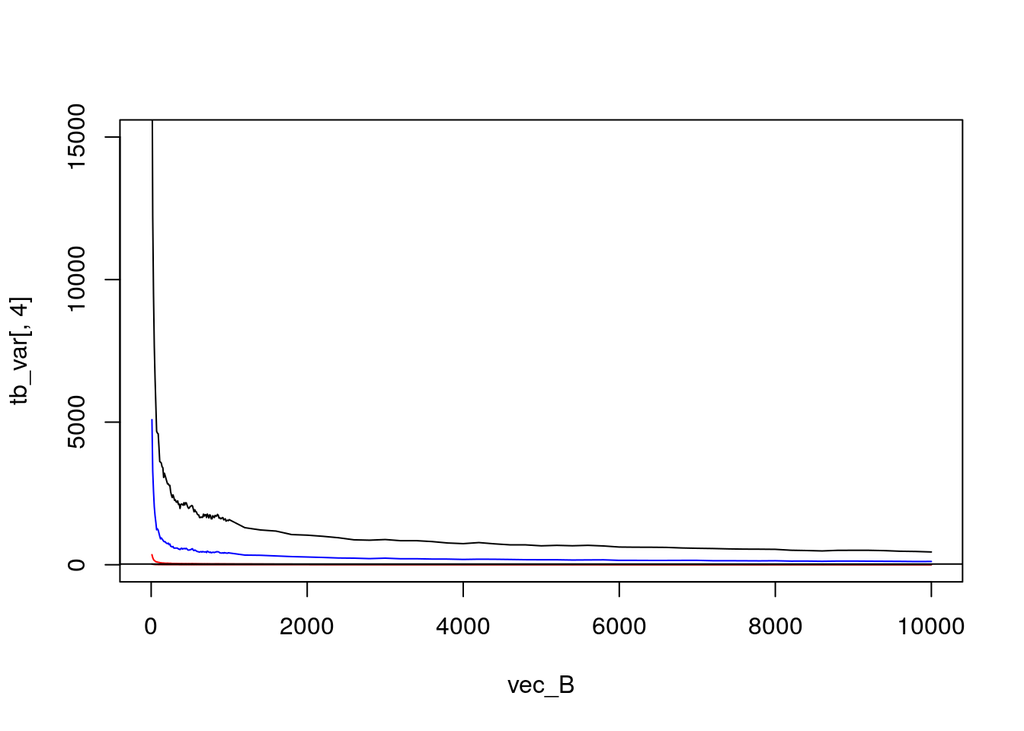

```r
xmin = 0
xmax = 10000
ymin = 0
ymax = 15000
plot(vec_B,tb_var[,4],type='l', xlim = c(xmin,xmax), ylim=c(ymin, ymax))
lines(vec_B,tb_var[,3],col='blue')
lines(vec_B,tb_var[,2],col='red')
lines(vec_B,tb_var[,1],col='darkred')
abline(h=26.14091,col='black')
```

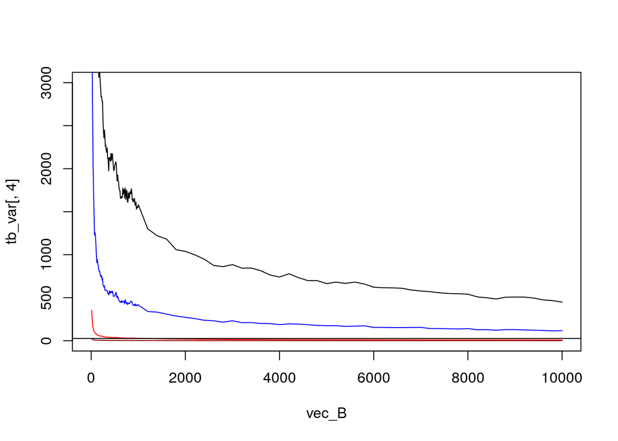

```r
xmin = 0
xmax = 10000
ymin = 0
ymax = 3000
plot(vec_B,tb_var[,4],type='l', xlim = c(xmin,xmax), ylim=c(ymin, ymax))
lines(vec_B,tb_var[,3],col='blue')
lines(vec_B,tb_var[,2],col='red')
lines(vec_B,tb_var[,1],col='darkred')
abline(h=26.14091,col='black')
```

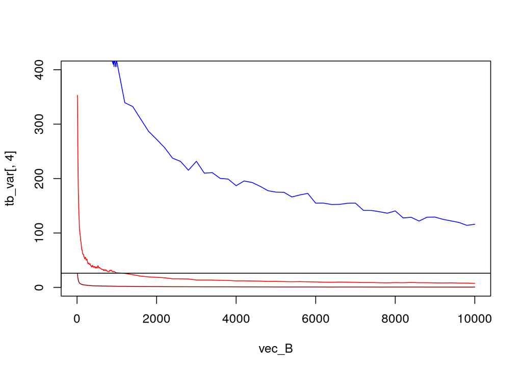

```r
xmin = 0
xmax = 10000
ymin = 0
ymax = 400
plot(vec_B,tb_var[,4],type='l', xlim = c(xmin,xmax), ylim=c(ymin, ymax))
lines(vec_B,tb_var[,3],col='blue')
lines(vec_B,tb_var[,2],col='red')
lines(vec_B,tb_var[,1],col='darkred')
abline(h=26.14091,col='black')
```

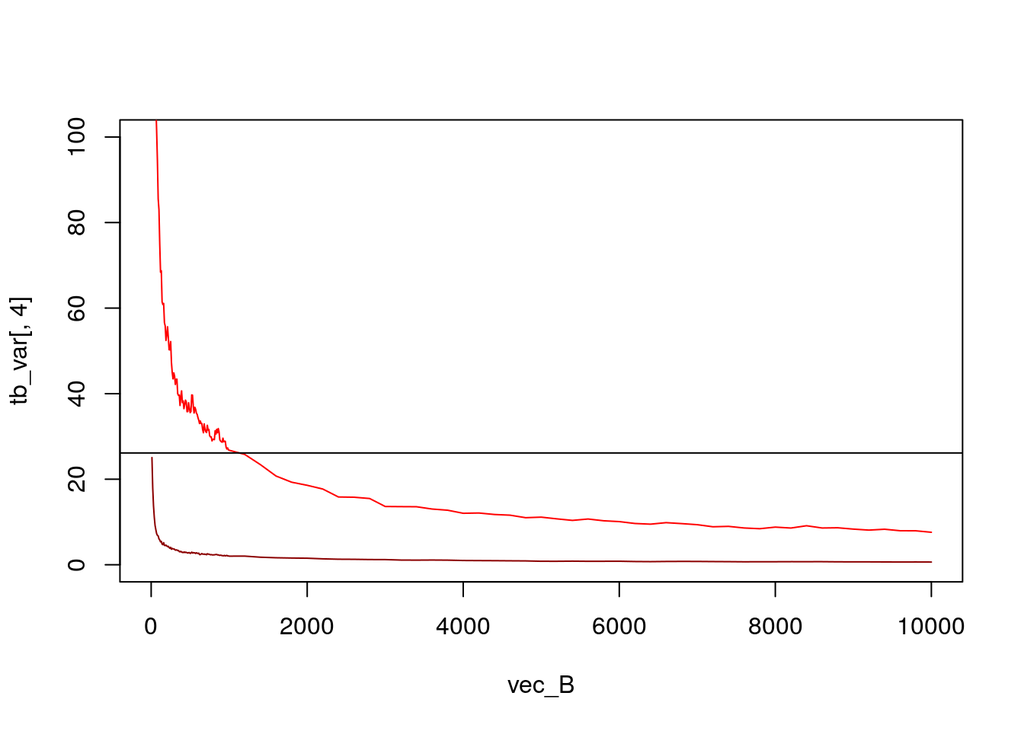

```r
xmin = 0
xmax = 10000
ymin = 0
ymax = 100
plot(vec_B,tb_var[,4],type='l', xlim = c(xmin,xmax), ylim=c(ymin, ymax))
lines(vec_B,tb_var[,3],col='blue')
lines(vec_B,tb_var[,2],col='red')
lines(vec_B,tb_var[,1],col='darkred')
abline(h=26.14091,col='black')
```

If we increase the size of sample the IPR decreases continuously.

After some point the gains in precision decreases that is maybe after a sample size of 1000 IPR decreases very slowly maybe the cost of increasing sample test size is not worth the gains in precision.

Let’s say we have a sample test of size 10,000 but we want to make bootstrap samples of size 1000, what are the problems of doing this? What if the variance of error is large? How this affect the stability of IPR?

# Ideas

Ideas for classification problem: we should first build a DGP that is about a classification problem. It is a binomial model. Then we test with the method of building a bootstrap inter percentile range and see how IPR changes with changing parameters of bootstrap procedure.